# Classification Models

## Discussion questions

Suppose you are developing a classification model to determine whether or not a person has a particular disease (based on symptoms, results of diagnostic tests, family history, risk factors, etc).

1. Explain what “precision” represents in this context.

**Discuss with your partner, and make notes here.** Of those that the model predicted positive, the ones who actually tested positive

2. Explain what “recall” represents in this context.

**Discuss with your partner, and make notes here.** Of all those who tested positive, the ones the model correctly predicted positive

3. Which of the following do you think is a more serious error? It’s an opinion question, but choose one and discuss.
- Concluding that a person has the disease if they actually don’t have it
- Failing to conclude that a person has the disease if they actually do have it

**Discuss with your partner, and make notes here.** Failing to conclude that a person has the disease, because this delays treatment and endangers the person

4. Given your answer to the previous question, which would you prefer to be higher: precision or recall?

**Discuss with your partner, and make notes here.** Recall, we want to identify as many people as possible that have the disease

5. Suppose you want to achieve higher recall. Should your classification rule be more or less strict about who it predicts to have the disease?

**Discuss with your partner, and make notes here.** Less strict

6. What is a downside to your choice in the previous part?

**Discuss with your partner, and make notes here.** More false positives leading to wasted additional testing resources

```python
import pandas as pd
import numpy as np
```

## More wine

The wines data set (https://dlsun.github.io/pods/data/wines.csv ) contains data about the chemical composition of various wines. We’ll first use just two features—fixed acidity and volatile acidity—to predict the color of the wine (red or white).

```python
df_train = pd.read_csv("https://dlsun.github.io/pods/data/wines.csv")

df_train
```

|  | fixed acidity | volatile acidity | citric acid | residual sugar | chlorides | free sulfur dioxide | total sulfur dioxide | density | pH | sulphates | alcohol | quality | color |
| --- | --- | --- | --- | --- | --- | --- | --- | --- | --- | --- | --- | --- | --- |
| 0 | 7.4 | 0.70 | 0.00 | 1.9 | 0.076 | 11.0 | 34.0 | 0.99780 | 3.51 | 0.56 | 9.4 | 5 | red |
| 1 | 7.8 | 0.88 | 0.00 | 2.6 | 0.098 | 25.0 | 67.0 | 0.99680 | 3.20 | 0.68 | 9.8 | 5 | red |
| 2 | 7.8 | 0.76 | 0.04 | 2.3 | 0.092 | 15.0 | 54.0 | 0.99700 | 3.26 | 0.65 | 9.8 | 5 | red |
| 3 | 11.2 | 0.28 | 0.56 | 1.9 | 0.075 | 17.0 | 60.0 | 0.99800 | 3.16 | 0.58 | 9.8 | 6 | red |
| 4 | 7.4 | 0.70 | 0.00 | 1.9 | 0.076 | 11.0 | 34.0 | 0.99780 | 3.51 | 0.56 | 9.4 | 5 | red |
| ... | ... | ... | ... | ... | ... | ... | ... | ... | ... | ... | ... | ... | ... |
| 6492 | 6.2 | 0.21 | 0.29 | 1.6 | 0.039 | 24.0 | 92.0 | 0.99114 | 3.27 | 0.50 | 11.2 | 6 | white |
| 6493 | 6.6 | 0.32 | 0.36 | 8.0 | 0.047 | 57.0 | 168.0 | 0.99490 | 3.15 | 0.46 | 9.6 | 5 | white |
| 6494 | 6.5 | 0.24 | 0.19 | 1.2 | 0.041 | 30.0 | 111.0 | 0.99254 | 2.99 | 0.46 | 9.4 | 6 | white |
| 6495 | 5.5 | 0.29 | 0.30 | 1.1 | 0.022 | 20.0 | 110.0 | 0.98869 | 3.34 | 0.38 | 12.8 | 7 | white |
| 6496 | 6.0 | 0.21 | 0.38 | 0.8 | 0.020 | 22.0 | 98.0 | 0.98941 | 3.26 | 0.32 | 11.8 | 6 | white |

6497 rows × 13 columns

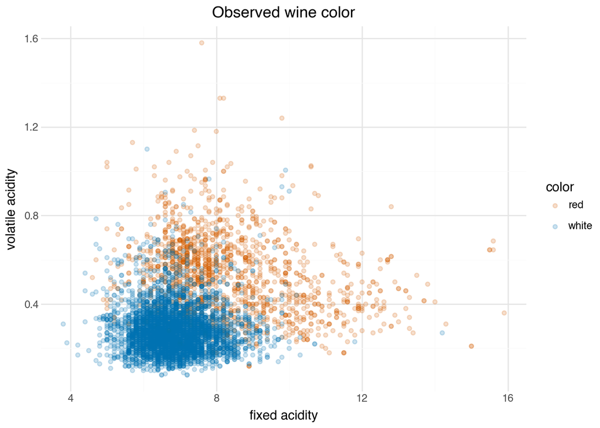

```python
from plotnine import *

(
    ggplot(df_train, aes(x="fixed acidity", y="volatile acidity", color="color"))
    + geom_point(alpha=0.2)
    + scale_color_manual(values={"red": "#D55E00", "white": "#0072B2"})
    + labs(title="Observed wine color")
    + theme_minimal()
)
```

1. Fit a 15-nearest neighbors model for predicting color from fixed acidity and volatile acidity. Don’t forget to scale the features. Create a scatter plot of the predicted wine colors for the training data, and compare visually to the observed colors.

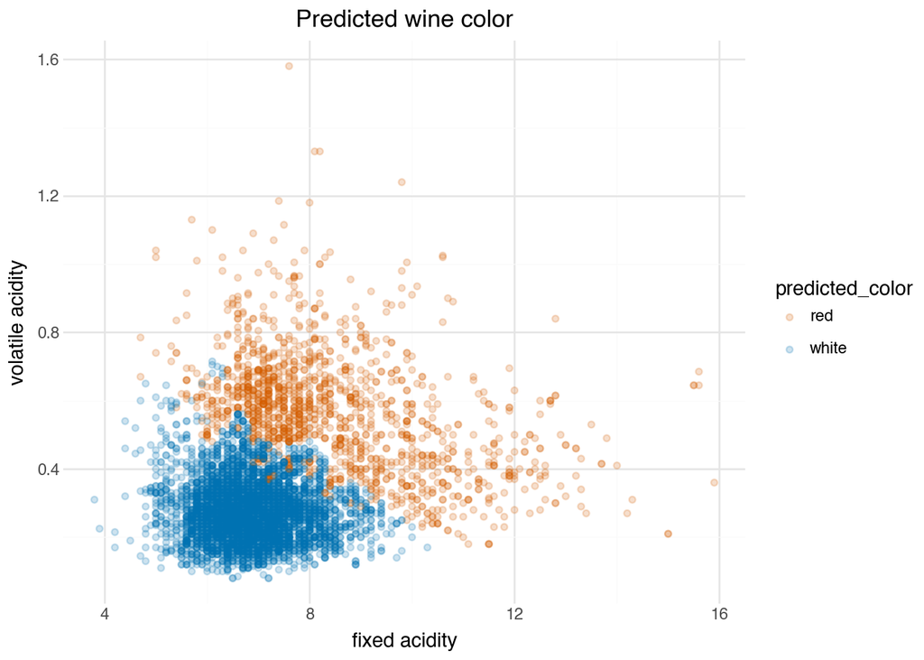

```python
# YOUR CODE HERE

from sklearn.neighbors import KNeighborsClassifier
from sklearn.preprocessing import StandardScaler
from sklearn.pipeline import make_pipeline

# Select predictors and target
X = df_train[["fixed acidity", "volatile acidity"]]
y = df_train["color"]

# Scale features and fit 15-nearest neighbors
knn_wine = make_pipeline(
    StandardScaler(),
    KNeighborsClassifier(n_neighbors=15)
)

knn_wine.fit(X, y)

# Predict wine color for training data
df_train["predicted_color"] = knn_wine.predict(X)

# Plot predicted wine colors
(
    ggplot(df_train, aes(x="fixed acidity", y="volatile acidity",
                         color="predicted_color"))
    + geom_point(alpha=0.2)
    + scale_color_manual(values={"red": "#D55E00", "white": "#0072B2"})
    + labs(title="Predicted wine color")
    + theme_minimal()
)
```

The predicted plot looks similar to the observed plot, but there is less overlap between red and white wines. The model predicts white wines mostly in areas with lower volatile acidity, while red wines are generally predicted in areas with higher volatile acidity and fixed acidity.

2. Use 10-fold cross-validation to estimate the test precision, recall, and F1 score using `macro` scoring.

```python
# YOUR CODE HERE
from sklearn.model_selection import cross_validate

# 10-fold cross-validation
cv_results = cross_validate(
    knn_wine,
    X,
    y,
    cv=10,
    scoring=["precision_macro", "recall_macro", "f1_macro"]
)

# Average scores across the 10 folds
print("Precision:", round(cv_results["test_precision_macro"].mean(), 4))
print("Recall:", round(cv_results["test_recall_macro"].mean(), 4))
print("F1 Score:", round(cv_results["test_f1_macro"].mean(), 4))
```

```
Precision: 0.8814
Recall: 0.8544
F1 Score: 0.8633
```

Using 10-fold cross-validation, our model had a macro precision of 88.14%, recall of 85.44%, and F1 score of 86.33%. This shows that our model does a pretty good job of predicting wine color, with precision being slightly higher than recall.

3. Use `GridSearchCV` to fit $k$-nearest neighbors models for $k=1,\ldots, 30$ and use cross validation to estimate the test F1 macro score. Plot the test score versus $k$. Which value of $k$ yields the best score?

```
Best k: 16
Best F1 Macro: 0.8664
```

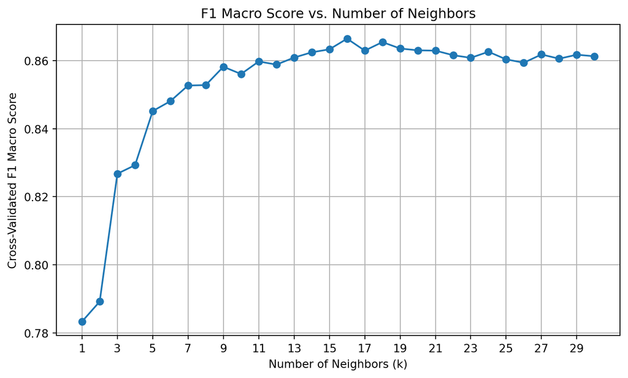

```python
# YOUR CODE HERE
import matplotlib.pyplot as plt
from sklearn.model_selection import GridSearchCV

# Test k values from 1 to 30
param_grid = {
    "kneighborsclassifier__n_neighbors": range(1, 31)
}

# Grid search using 10-fold cross-validation
grid_search = GridSearchCV(
    knn_wine,
    param_grid,
    cv=10,
    scoring="f1_macro"
)

# Fit the models
grid_search.fit(X, y)

# Display best results
print("Best k:", grid_search.best_params_["kneighborsclassifier__n_neighbors"])
print("Best F1 Macro:", round(grid_search.best_score_, 4))

# Create dataframe of results
grid_results = pd.DataFrame(grid_search.cv_results_)

# Plot F1 score versus k
plt.figure(figsize=(9, 5))

plt.plot(
    grid_results["param_kneighborsclassifier__n_neighbors"].astype(int),
    grid_results["mean_test_score"],
    marker="o"
)

plt.xlabel("Number of Neighbors (k)")
plt.ylabel("Cross-Validated F1 Macro Score")
plt.title("F1 Macro Score vs. Number of Neighbors")
plt.xticks(range(1, 31, 2))
plt.grid(True)
plt.show()
```

The best value of k was 16, which resulted in an F1 macro score of 86.64%. This was the highest score out of the 30 values tested using 10-fold cross-validation.

4. When the target variable is binary **logistic regression** provides another classification algorithm.

Fit a logistic regression model for predicting wine color from the two features. Create a scatter plot of the predicted wine colors for the training data, and compare visually to the predictions from the nearest neighbors classifier.

Note: with regression, you don’t need to scale the features (unless you add a penalty). Hint: you basically just need to replace with `KNeighborsClassifier()` with `LogisticRegression()`.

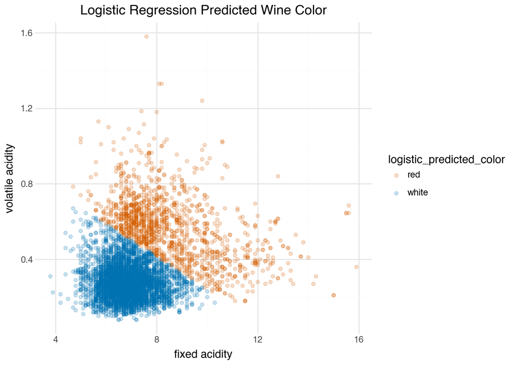

```python
from sklearn.linear_model import LogisticRegression

# YOUR CODE HERE

# Fit logistic regression model
log_model = LogisticRegression(penalty=None, max_iter=1000)
log_model.fit(X, y)

# Predict wine colors
df_train["logistic_predicted_color"] = log_model.predict(X)

# Plot predicted wine colors
(
    ggplot(df_train, aes(x="fixed acidity", y="volatile acidity",
                         color="logistic_predicted_color"))
    + geom_point(alpha=0.2)
    + scale_color_manual(values={"red": "#D55E00", "white": "#0072B2"})
    + labs(title="Logistic Regression Predicted Wine Color")
    + theme_minimal()
)
```

The logistic regression predictions look similar to the KNN predictions, but logistic regression creates a straighter separation between red and white wines. KNN has more overlap in the predicted colors because it uses the nearest neighbors, while logistic regression uses the overall relationship between acidity and wine color.

5. Use 10-fold cross-validation to estimate the test precision, recall, and F1 score of the logistic regression model using `macro` scoring. Compare to the nearest neighbors model.

```python
# YOUR CODE HERE

from sklearn.model_selection import cross_validate

# 10-fold cross-validation for logistic regression
cv_log = cross_validate(
    log_model,
    X,
    y,
    cv=10,
    scoring=["precision_macro", "recall_macro", "f1_macro"]
)

# Compare logistic regression with KNN
print("Logistic Regression:")
print("Precision:", round(cv_log["test_precision_macro"].mean(), 4))
print("Recall:", round(cv_log["test_recall_macro"].mean(), 4))
print("F1 Score:", round(cv_log["test_f1_macro"].mean(), 4))

print("\n15-Nearest Neighbors:")
print("Precision:", round(cv_results["test_precision_macro"].mean(), 4))
print("Recall:", round(cv_results["test_recall_macro"].mean(), 4))
print("F1 Score:", round(cv_results["test_f1_macro"].mean(), 4))
```

```
Logistic Regression:
Precision: 0.8917
Recall: 0.8522
F1 Score: 0.8646

15-Nearest Neighbors:
Precision: 0.8814
Recall: 0.8544
F1 Score: 0.8633
```

Logistic regression performed slightly better than KNN in precision and F1 score, while KNN had slightly higher recall. The scores were very close, but logistic regression had the higher F1 score at 86.46% compared to 86.33% for KNN.

6. Now fit a logistic regression model using all of the potential predictors. Use 10-fold cross-validation to estimate the test precision, recall, and F1 score of the logistic regression model using `macro` scoring.

```python
# YOUR CODE HERE

from sklearn.linear_model import LogisticRegression
from sklearn.preprocessing import StandardScaler
from sklearn.pipeline import make_pipeline
from sklearn.model_selection import cross_validate

# Use all predictors except the target and previous predictions
X_all = df_train.drop(
    columns=["color", "predicted_color", "logistic_predicted_color"],
    errors="ignore"
)

y_all = df_train["color"]

# Logistic regression model
log_all = make_pipeline(
    StandardScaler(),
    LogisticRegression(penalty=None, max_iter=3000)
)

# Fit the model
log_all.fit(X_all, y_all)

# 10-fold cross-validation
cv_all = cross_validate(
    log_all,
    X_all,
    y_all,
    cv=10,
    scoring=["precision_macro", "recall_macro", "f1_macro"]
)

# Display results
print("All Predictors Logistic Regression:")
print("Precision:", round(cv_all["test_precision_macro"].mean(), 4))
print("Recall:", round(cv_all["test_recall_macro"].mean(), 4))
print("F1 Score:", round(cv_all["test_f1_macro"].mean(), 4))

print("\nPrevious Logistic Regression (2 predictors):")
print("Precision:", round(cv_log["test_precision_macro"].mean(), 4))
print("Recall:", round(cv_log["test_recall_macro"].mean(), 4))
print("F1 Score:", round(cv_log["test_f1_macro"].mean(), 4))
```

```
All Predictors Logistic Regression:
Precision: 0.9923
Recall: 0.9894
F1 Score: 0.9908

Previous Logistic Regression (2 predictors):
Precision: 0.8917
Recall: 0.8522
F1 Score: 0.8646
```

Using all the predictors significantly improved the logistic regression model. Precision increased to 99.23%, recall increased to 98.94%, and the F1 score increased to 99.08%. This shows that the additional wine characteristics help the model predict wine color much more accurately than using only the two acidity variables.

7. Now fit a logistic regression model using all of the potential predictors with a LASSO (`"l1"`) penalty. Use 10-fold cross-validation to estimate the test precision, recall, and F1 score of the logistic regression model using `macro` scoring.

```python
# YOUR CODE HERE

from sklearn.linear_model import LogisticRegression
from sklearn.preprocessing import StandardScaler
from sklearn.pipeline import make_pipeline
from sklearn.model_selection import cross_validate

# Logistic regression with LASSO penalty
lasso_model = make_pipeline(
    StandardScaler(),
    LogisticRegression(
        penalty="l1",
        solver="liblinear",
        max_iter=3000
    )
)

# Fit model using all predictors
lasso_model.fit(X_all, y_all)

# 10-fold cross-validation
cv_lasso = cross_validate(
    lasso_model,
    X_all,
    y_all,
    cv=10,
    scoring=["precision_macro", "recall_macro", "f1_macro"]
)

# Display results
print("LASSO Logistic Regression:")
print("Precision:", round(cv_lasso["test_precision_macro"].mean(), 4))
print("Recall:", round(cv_lasso["test_recall_macro"].mean(), 4))
print("F1 Score:", round(cv_lasso["test_f1_macro"].mean(), 4))

print("\nPrevious Logistic Regression (No Penalty):")
print("Precision:", round(cv_all["test_precision_macro"].mean(), 4))
print("Recall:", round(cv_all["test_recall_macro"].mean(), 4))
print("F1 Score:", round(cv_all["test_f1_macro"].mean(), 4))
```

```
LASSO Logistic Regression:
Precision: 0.9922
Recall: 0.9904
F1 Score: 0.9913

Previous Logistic Regression (No Penalty):
Precision: 0.9923
Recall: 0.9894
F1 Score: 0.9908
```